# 1.5 Stem-and-Leaf Plots, Bar Charts, Dot Plots, and Histograms

## Objectives

- Create, analyze, and interpret statistical graphs including histograms, dot plots, stem-and-leaf plots, box plots, and scatter plots.
- Analyze an application in the disciplines business, social sciences, psychology, life sciences, health science, and education, and utilize the correct statistical processes to arrive at a solution.

## Frequency

Once you have a set of data, you will need to organize it so that you can analyze how frequently each datum occurs in the set. A **frequency** is the number of times a value of the data occurs.

For example, imagine twenty students were asked how many hours they worked per day. Their responses, in hours, are as follows:

5; 6; 3; 3; 2; 4; 7; 5; 2; 3; 5; 6; 5; 4; 4; 3; 5; 2; 5; 3

By counting the number of times each value occurs, we can construct a **frequency table**.

| HOURS WORKED PER DAY | FREQUENCY |
| --- | --- |
| 2 | 3 |
| 3 | 5 |
| 4 | 3 |
| 5 | 6 |
| 6 | 2 |
| 7 | 1 |
|  | **Total = 20** |

By inspecting the table, we see that 6 of the students that were surveyed worked 5 hours per day.

A **relative frequency** is the ratio (fraction or proportion) of the number of times a value of the data occurs in the set of all outcomes to the total number of outcomes. To find the relative frequencies, divide each frequency by the total number of students in the sample–in this case, 20. Relative frequencies can be written as fractions, percents, or decimals.

| HOURS WORKED PER DAY | FREQUENCY | RELATIVE FREQUENCY |
| --- | --- | --- |
| 2 | 3 | $\dfrac{3}{20}$ or 0.15 |
| 3 | 5 | $\dfrac{5}{20}$ or 0.25 |
| 4 | 3 | $\dfrac{3}{20}$ or 0.15 |
| 5 | 6 | $\dfrac{6}{20}$ or 0.30 |
| 6 | 2 | $\dfrac{2}{20}$ or 0.10 |
| 7 | 1 | $\dfrac{1}{20}$ or 0.05 |
|  | **Total = 20** | **Total = 1.00** |

Note that the sum of the relative frequencies should always add up to 1.00 or 100%. We could also **group** data and calculate the frequency and relative frequency for each group. For example, the table below represents the heights, in inches, of a sample of 100 male semiprofessional soccer players.

| HEIGHTS (INCHES) | FREQUENCY | RELATIVE FREQUENCY |  |
| --- | --- | --- | --- |
| 59.95–61.95 | 5 | $\dfrac{5}{100}$ = 0.05 |  |
| 61.95–63.95 | 3 | $\dfrac{3}{100}$ = 0.03 |  |
| 63.95–65.95 | 15 | $\dfrac{15}{100}$ = 0.15 |  |
| 65.95–67.95 | 40 | $\dfrac{40}{100}$ = 0.40 |  |
| 67.95–69.95 | 17 | $\dfrac{17}{100}$ = 0.17 |  |
| 69.95–71.95 | 12 | $\dfrac{12}{100}$ = 0.12 |  |
| 71.95–73.95 | 7 | $\dfrac{7}{100}$ = 0.07 |  |
| 73.95–75.95 | 1 | $\dfrac{1}{100}$ = 0.01 |  |
|  | **Total = 100** | **Total = 1.00** |  |

So a soccer player in the sample that is 64.5 inches tall will be counted in the group of athletes with heights between 63.95-65.95 inches.

## Dot Plots

Once you have organized your data, it can be useful to present the data graphically. When working by hand with a small amount of data, a quick way to present the group or category frequencies graphically is a **dot plot**. To construct a dot plot, simply draw a stack of dots equal to the group frequency for each group.

Dot plots were more common before the advent of the personal computer, but they can still be helpful for a quick analysis of data.

### Example 5.1

Fourteen students were asked the average time (in hours, to the nearest half-hour) they sleep per night. Here is the data the was obtained:

5; 5.5; 6; 6; 6; 6.5; 6.5; 6.5; 6.5; 7; 7; 8; 8; 9

Construct a dot plot of the data. Where do the data tend to cluster?

#### Solution

[figure not shown]

Examing the dot plot, the data appear to cluster around 6-7 hours of sleep per night.

## Bar Charts

For qualitative or categorical data, **Bar charts** or **bar graphs** can be used to visualize the frequency or relative frequency of each category. In a bar chart, each category has a rectangular bar associated with it, where the height of the bar (or the width of the bar, for a horizontal bar chart) represents the frequency or relative frequency of the category. The bars in a bar chart are separated by a small space or gap.

We can use R to construct a bar chart for us by specifying both the categories and their frequencies or relative frequencies. We can use the `barplot` function:

```
barplot(height, names, main, xlab, ylab, col)
```

Here, `height` is a list of the heights (the frequencies or relative frequencies) of each bar, and `names` is the corresponding list of categories. The `height` list and the `names` list must be in the same order.

Arguments `main`, `xlab`, `ylab`, and `col` are optional but recommended.

- `main` is the main title of the graph
- `xlab` is the $x$-axis label
- `ylab` is the $y$-axis label
- `col` allows us to choose the color of the bars. [There are hundreds of colors to choose from](http://www.stat.columbia.edu/~tzheng/files/Rcolor.pdf), including all standard colors ("red", "orange", "yellow", "green", "blue", "purple", "white", "black", "gray").

### Example 5.2

The population in Park City is made up of children, working-age adults, and retirees. The table below shows the three age groups, the number of people in the town from each age group, and the proportion (%) of people in each age group. Construct a bar graph showing the proportions.

**Table 5.1:** Population in Park City by age group.

| Age groups | Number of people | Proportion of population |
| --- | --- | --- |
| Children | 67,059 | 19% |
| Working-age adults | 152,198 | 43% |
| Retirees | 131,662 | 38% |

#### Solution

In this example, we have three categories of age groups ("Children", "Working-age adults", "Retirees"). We are given the frequency of each age group in the "Number of people" column and the relative frequency in the "Proportion of the population" column. We will use R to construct a bar graph of the relative frequencies of each category.

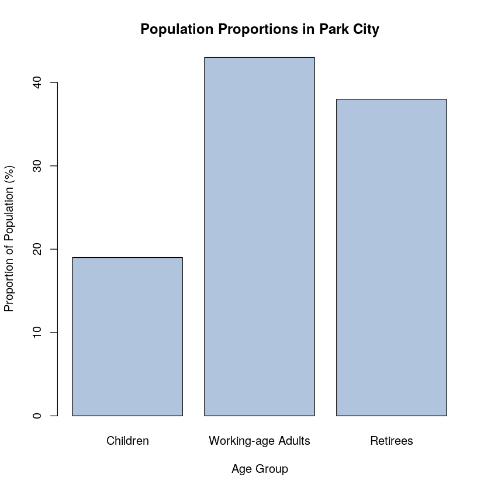

```r
age_groups <- c("Children", "Working-age Adults", "Retirees")
proportions <- c(19, 43, 38)

barplot(height = proportions,
        names = age_groups,
        main = "Population Proportions in Park City",
        xlab = "Age Group",
        ylab = "Proportion of Population (%)",
        col = "lightsteelblue")
```

### Example 5.3

The columns in the table below contain: the race or ethnicity of students in U.S. Public Schools for the class of 2011, percentages for the Advanced Placement examine population for that class, and percentages for the overall student population. Create a bar graph with the student race or ethnicity (qualitative data) on the x-axis, and the Advanced Placement examinee population percentages on the y-axis.

**Table 5.2:**

| Race/Ethnicity | AP Examinee Population | Overall Student Population |
| --- | --- | --- |
| 1 = Asian, Asian American or Pacific Islander | 10.3% | 5.7% |
| 2 = Black or African American | 9.0% | 14.7% |
| 3 = Hispanic or Latino | 17.0% | 17.6% |
| 4 = American Indian or Alaska Native | 0.6% | 1.1% |
| 5 = White | 57.1% | 59.2% |
| 6 = Not reported/other | 6.0% | 1.7% |

#### Solution

This table provides us with the relative frequecy of each ethnicity in two different populations: the population of all AP examinees and the overall student population. In this case, we will only use the data in the "AP Examinee Population" column to construct our bar chart; we will not use the "Overall Student Population" data in this example.

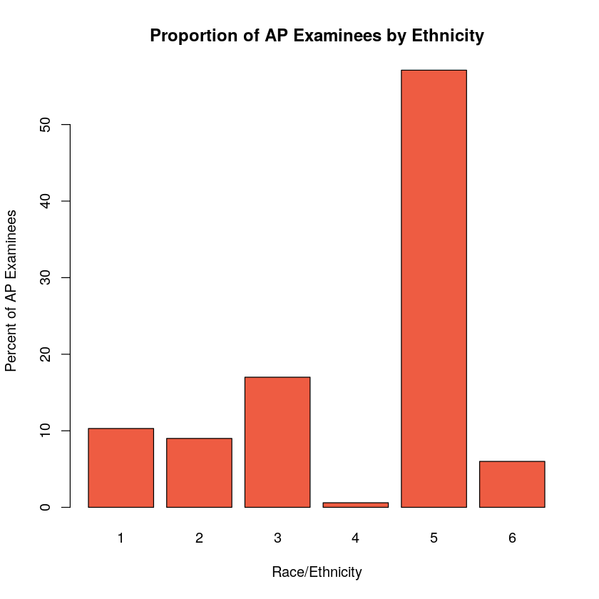

```r
race <- c(1, 2, 3, 4, 5, 6)
APproportion <- c(10.3, 9.0, 17.0, 0.6, 57.1, 6.0)

barplot(height = APproportion,
        names = race,
        main = "Proportion of AP Examinees by Ethnicity",
        xlab = "Race/Ethnicity",
        ylab = "Percent of AP Examinees",
        col = "tomato2")
```

## Stem-and-Leaf Graphs

We apporach graphs for quantitative data similarly, though with a few important distinctions.

First, with quantitative data, it is often up to the statistician how to group or categorize the data. For example, if we are gathering data on eye color (qualitative data), we naturally have a category of blue eyes and a category of brown eyes; there is no opportunity adjust the categories. But if we are gathering data on the heights of adult males (quantitative data), the statistician could partition the data so they get a group of individuals 50-59 inches tall, or they could partition the data so they get a group of individuals 50-54 inches tall and another group of individuals 55-59 inches tall.

Second, we can measure how far apart quantitative data is. It doesn't make sense to ask how far apart blue eyes are from brown eyes. But it does make sense to ask how far apart 50 inches is from 59 inches (they are 59 - 50 = 9 inches apart).

One simple graph used to visualize quantitative data, the **stem-and-leaf graph** or **stemplot**, comes from the field of exploratory data analysis. It is a good choice when the data sets are small. To create the plot, divide each observation of data into a stem and a leaf. The leaf consists of a final **significant digit**. For example, 23 has stem two and leaf three. The number 432 has stem 43 and leaf two. Likewise, the number 5,432 has stem 543 and leaf two. The decimal 9.3 has stem nine and leaf three. Write the stems in a vertical line from smallest to largest. Draw a vertical line to the right of the stems. Then write the leaves in increasing order next to their corresponding stem.

### Example 5.4

For Susan Dean's spring pre-calculus class, scores for the first exam were as follows (smallest to largest):

33; 42; 49; 49; 53; 55; 55; 61; 63; 67; 68; 68; 69; 69; 72; 73; 74; 78; 80; 83; 88; 88; 88; 90; 92; 94; 94; 94; 94; 96; 100

We can easily construct the stem-and-leaf plot for this data by hand:

| Stem | Leaf |
| --- | --- |
| 3 | 3 |
| 4 | 2 9 9 |
| 5 | 3 5 5 |
| 6 | 1 3 7 8 8 9 9 |
| 7 | 2 3 4 8 |
| 8 | 0 3 8 8 8 |
| 9 | 0 2 4 4 4 4 6 |
| 10 | 0 |

By presenting the data graphically, we can see that most scores fell in the 60s, 70s, 80s, and 90s.

The stemplot is a quick way to graph data and gives an exact picture of the data. You want to look for an overall pattern and any outliers. An **outlier** is an observation of data that does not fit the rest of the data. It is sometimes called an **extreme value**. When you graph an outlier, it will appear not to fit the pattern of the graph. Some outliers are due to mistakes (for example, writing down 50 instead of 500) while others may indicate that something unusual is happening. It takes some background information to explain outliers, so we will cover them in more detail later.

### Example 5.5

The data are the distances (in kilometers) from a home to local supermarkets. Create a stemplot using the data:

1.1; 1.5; 2.3; 2.5; 2.7; 3.2; 3.3; 3.3; 3.5; 3.8; 4.0; 4.2; 4.5; 4.5; 4.7; 4.8; 5.5; 5.6; 6.5; 6.7; 12.3

Do the data seem to have any concentration of values? Do there appear to be any outliers in the data?

#### Solution

| Stem | Leaf |
| --- | --- |
| 1 | 1 5 |
| 2 | 3 5 7 |
| 3 | 2 3 3 5 8 |
| 4 | 0 2 5 5 7 8 |
| 5 | 5 6 |
| 6 | 5 7 |
| 7 |  |
| 8 |  |
| 9 |  |
| 10 |  |
| 11 |  |
| 12 | 3 |

**Note:** The leaves are to the right of the decimal.

The values appear to concentrate at three and four kilometers. The value 12.3 appears to be an outlier.

## Histograms

For most of the work you do in this book, you will use a histogram to display the data. One advantage of a histogram is that it can readily display large data sets. A rule of thumb is to use a histogram when the data set consists of 100 values or more.

A **histogram** is similar to a bar chart, but it is a better way to visualize quantitative data. Unlike a bar chart, a histogram consists of contiguous (adjoining) boxes so there is no gap between the bars. This helps emphasize the "distance" between quantitative data. A histogram has both a horizontal axis and a vertical axis. The horizontal axis is labeled with what the data represents (for instance, distance from your home to school). The vertical axis is labeled either frequency or relative frequency (or percent frequency or probability). The graph will have the same shape with either label. The histogram (like the stemplot) can give you the shape of the data, the center, and the spread of the data.

We will have R construct our histograms for us. To construct a histogram in R, use the `hist` function:

```
hist(x, main, xlab, ylab, col)
```

Here, `x` is the list of data we want a histogram of. Arguments `main`, `xlab`, `ylab`, and `col` perform exactly the same functions as they do in the `barplot` function above; as above, these arguments are not required but recommended.

### Example 5.6

The following data are the heights (in inches to the nearest half inch) of 100 male semiprofessional soccer players. The heights are continuous data, since height is measured.

60, 60.5, 61, 61, 61.5, 63.5, 63.5, 63.5, 64, 64, 64, 64, 64, 64, 64, 64.5, 64.5, 64.5, 64.5, 64.5, 64.5, 64.5, 64.5, 66, 66, 66, 66, 66, 66, 66, 66, 66, 66, 66.5, 66.5, 66.5, 66.5, 66.5, 66.5, 66.5, 66.5, 66.5, 66.5, 66.5, 67, 67, 67, 67, 67, 67, 67, 67, 67, 67, 67, 67, 67.5, 67.5, 67.5, 67.5, 67.5, 67.5, 68, 68, 69, 69, 69, 69, 69, 69, 69, 69, 69, 69, 69.5, 69.5, 69.5, 69.5, 69.5, 70, 70, 70, 70, 70, 70, 70.5, 70.5, 70.5, 71, 71, 71, 72, 72, 72, 72.5, 72.5, 73, 73.5, 74

Construct a histogram of the data. Where do the data seem to be concentrated?

#### Solution

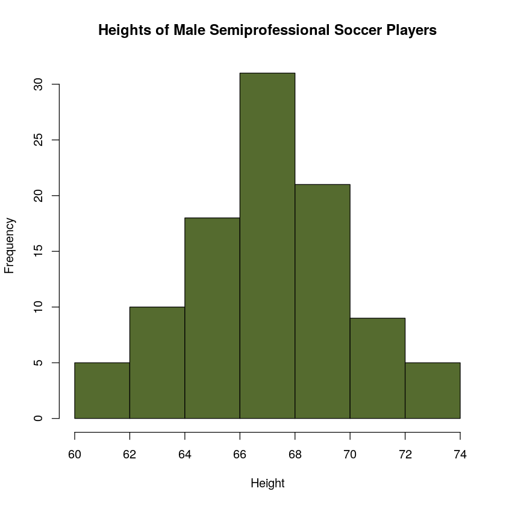

```r
data <- c(60, 60.5, 61, 61, 61.5, 63.5, 63.5, 63.5, 64, 64, 64, 64, 64, 64, 64, 64.5, 64.5, 64.5, 64.5, 64.5, 64.5, 64.5, 64.5, 66, 66, 66, 66, 66, 66, 66, 66, 66, 66, 66.5, 66.5, 66.5, 66.5, 66.5, 66.5, 66.5, 66.5, 66.5, 66.5, 66.5, 67, 67, 67, 67, 67, 67, 67, 67, 67, 67, 67, 67, 67.5, 67.5, 67.5, 67.5, 67.5, 67.5, 68, 68, 69, 69, 69, 69, 69, 69, 69, 69, 69, 69, 69.5, 69.5, 69.5, 69.5, 69.5, 70, 70, 70, 70, 70, 70, 70.5, 70.5, 70.5, 71, 71, 71, 72, 72, 72, 72.5, 72.5, 73, 73.5, 74)

hist(x = data,
     main = "Heights of Male Semiprofessional Soccer Players",
     xlab = "Height",
     col = "darkolivegreen")
```

**Note:** We did not specify `ylab` in the R code in this example. "Frequency" is the default label for the y-axis of a histogram.

**Note:** For histograms in R, each bar represents the frequency of values that lie between the endpoints to left and rigt of the bar, but *not including* the endpoint to the left and *including* the value to the right. For example, the bar between 70 and 72 counts only the data 70.5, 70.5, 70.5, 71, 71, 71, 72, 72, 72. So it includes the data points of value 72 (the right endpoint) but not the data points of value 70 (the left endpoint). The one exception to this rule is the bar on the far left, which includes both endpoints.

From the histogram, we can see that most of the players' heights are between 64 inches and 70 inches.

### Example 5.7

Create a histogram for the following data: the number of books bought by 50 part-time college students at ABC College.the number of books bought by 50 part-time college students at ABC College. The number of books is discrete data, since books are counted.

0, 0, 1, 1, 1, 1, 1, 1, 1, 1, 1, 2, 2, 2, 2, 2, 2, 2, 2, 2, 2, 3, 3, 3, 3, 3, 3, 3, 3, 3, 3, 3, 3, 3, 3, 3, 3, 4, 4, 4, 4, 4, 4, 5, 5, 5, 5, 5, 6, 6

#### Solution

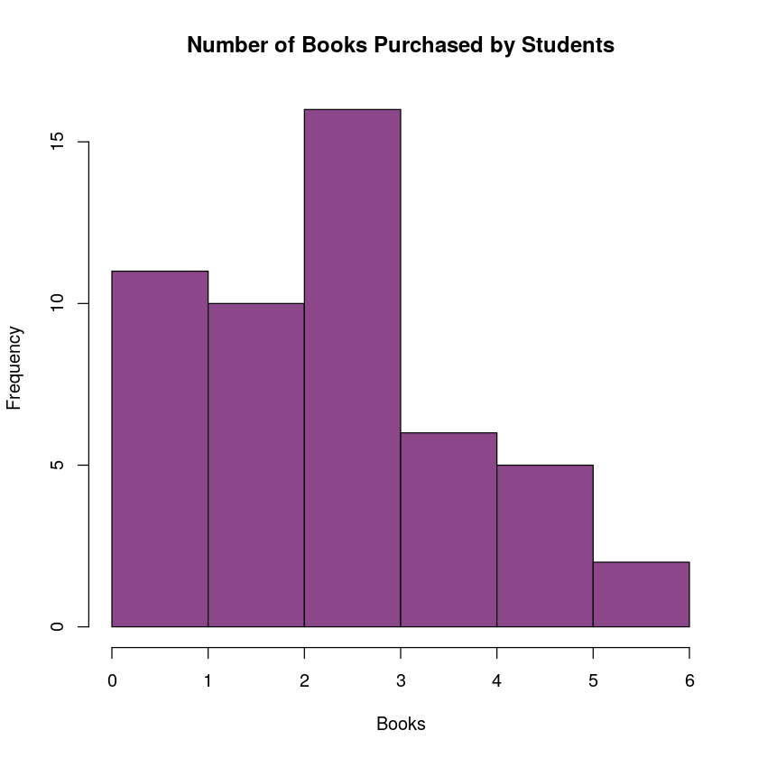

```r
books <- c(0, 0, 1, 1, 1, 1, 1, 1, 1, 1, 1, 2, 2, 2, 2, 2, 2, 2, 2, 2, 2, 3, 3, 3, 3, 3, 3, 3, 3, 3, 3, 3, 3, 3, 3, 3, 3, 4, 4, 4, 4, 4, 4, 5, 5, 5, 5, 5, 6, 6)

hist(x = books,
     main = "Number of Books Purchased by Students",
     xlab = "Books",
     col = "orchid4")
```

## Attribution

Significant portions of this textbook were written by Barbara Illowsky and Susan Dean in their textbook *Introductory Statistics*, published by OpenStax.

Access for free at https://openstax.org/books/introductory-statistics/pages/1-introduction